# Assignment_4

AZM

8/19/2022

# Library Load In

```r
library(tidyverse)
library(openintro)
data("fastfood", package='openintro')
head(fastfood)
```

| restaurant | item | calories | cal_fat | total_fat | sat_fat | trans_fat | cholesterol | sodium | total_carb | fiber | sugar | protein | vit_a | vit_c | calcium | salad |
| --- | --- | --- | --- | --- | --- | --- | --- | --- | --- | --- | --- | --- | --- | --- | --- | --- |
| Mcdonalds | Artisan Grilled Chicken Sandwich | 380 | 60 | 7 | 2 | 0.0 | 95 | 1110 | 44 | 3 | 11 | 37 | 4 | 20 | 20 | Other |
| Mcdonalds | Single Bacon Smokehouse Burger | 840 | 410 | 45 | 17 | 1.5 | 130 | 1580 | 62 | 2 | 18 | 46 | 6 | 20 | 20 | Other |
| Mcdonalds | Double Bacon Smokehouse Burger | 1130 | 600 | 67 | 27 | 3.0 | 220 | 1920 | 63 | 3 | 18 | 70 | 10 | 20 | 50 | Other |
| Mcdonalds | Grilled Bacon Smokehouse Chicken Sandwich | 750 | 280 | 31 | 10 | 0.5 | 155 | 1940 | 62 | 2 | 18 | 55 | 6 | 25 | 20 | Other |
| Mcdonalds | Crispy Bacon Smokehouse Chicken Sandwich | 920 | 410 | 45 | 12 | 0.5 | 120 | 1980 | 81 | 4 | 18 | 46 | 6 | 20 | 20 | Other |
| Mcdonalds | Big Mac | 540 | 250 | 28 | 10 | 1.0 | 80 | 950 | 46 | 3 | 9 | 25 | 10 | 2 | 15 | Other |

# Exercise 1

## Make a plot (or plots) to visualize the distributions of the amount of calories from fat of the options from these two restaurants. How do their centers, shapes, and spreads compare?

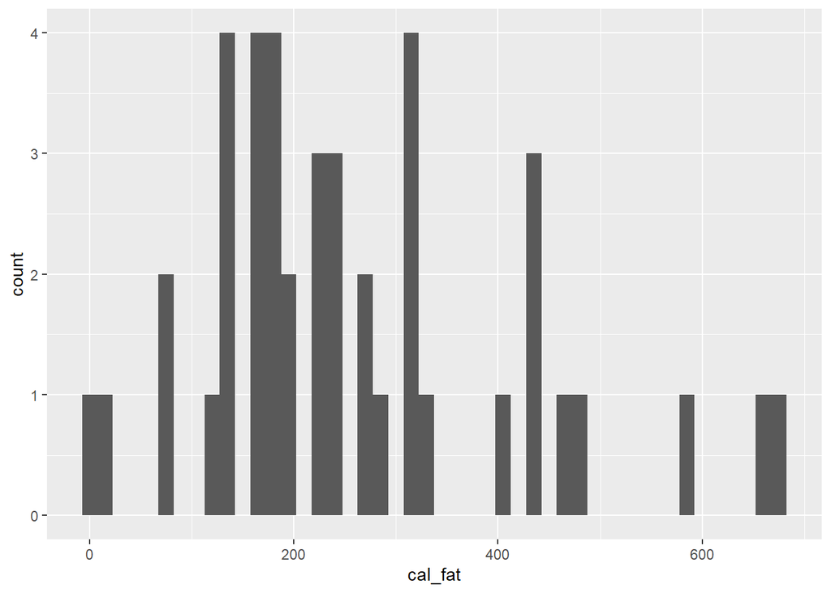

```r
mcdonalds <- fastfood %>%
  filter(restaurant == "Mcdonalds")
dairy_queen <- fastfood %>%
  filter(restaurant == "Dairy Queen")
ggplot(data = dairy_queen, aes(x = cal_fat)) +
  geom_histogram(binwidth = 15)
```

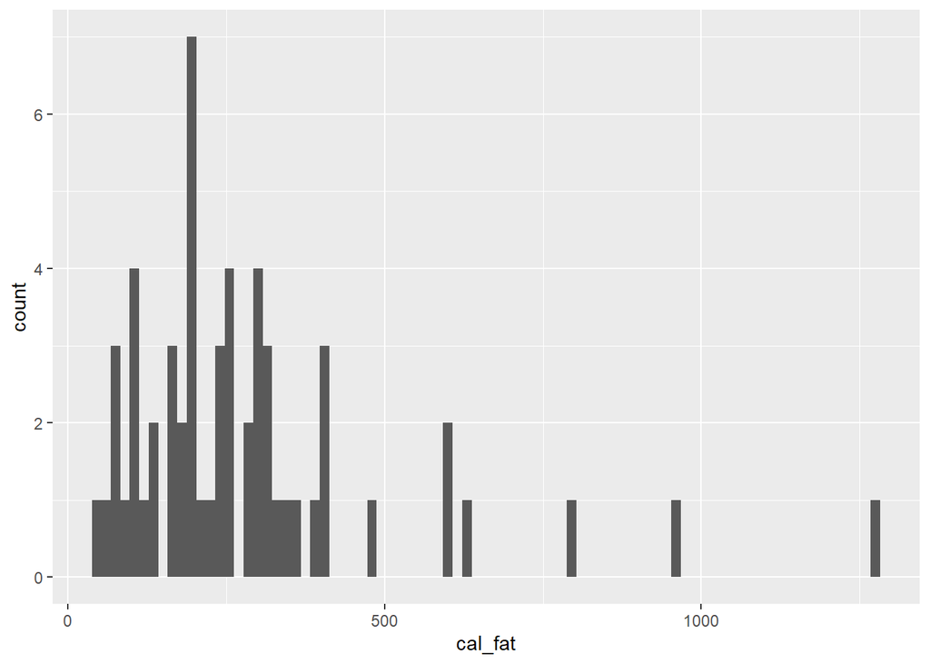

```r
ggplot(data = mcdonalds, aes(x = cal_fat)) +
  geom_histogram(binwidth = 15)
```

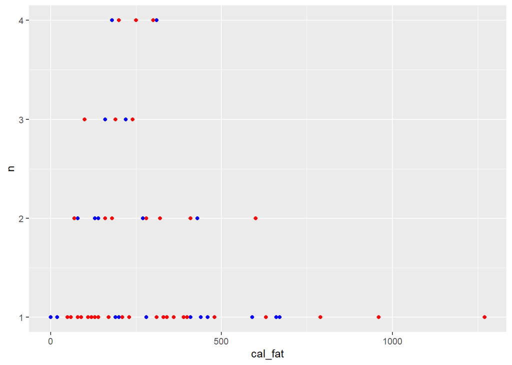

```r
dairy_queen_counts <- fastfood %>%
  filter(restaurant == "Dairy Queen") %>% count(cal_fat)
mcdonalds_counts <- fastfood %>%
    filter(restaurant == "Mcdonalds") %>% count(cal_fat)


ggplot() +
  geom_point(data = dairy_queen_counts, aes(x = cal_fat, y = n), color = "blue") +
  geom_point(data = mcdonalds_counts, aes(x = cal_fat, y = n), color = "red")
```

```r
fastFoodSubset <- fastfood %>%
  filter(restaurant == "Mcdonalds" | restaurant == "Dairy Queen") %>%
  count(restaurant, cal_fat)
fastFoodSubset
```

| restaurant | cal_fat | n |
| --- | --- | --- |
| Dairy Queen | 0 | 1 |
| Dairy Queen | 20 | 1 |
| Dairy Queen | 80 | 2 |
| Dairy Queen | 120 | 1 |
| Dairy Queen | 130 | 2 |
| Dairy Queen | 140 | 2 |
| Dairy Queen | 160 | 3 |
| Dairy Queen | 170 | 1 |
| Dairy Queen | 180 | 4 |
| Dairy Queen | 190 | 1 |

[output cut: 50 more lines]

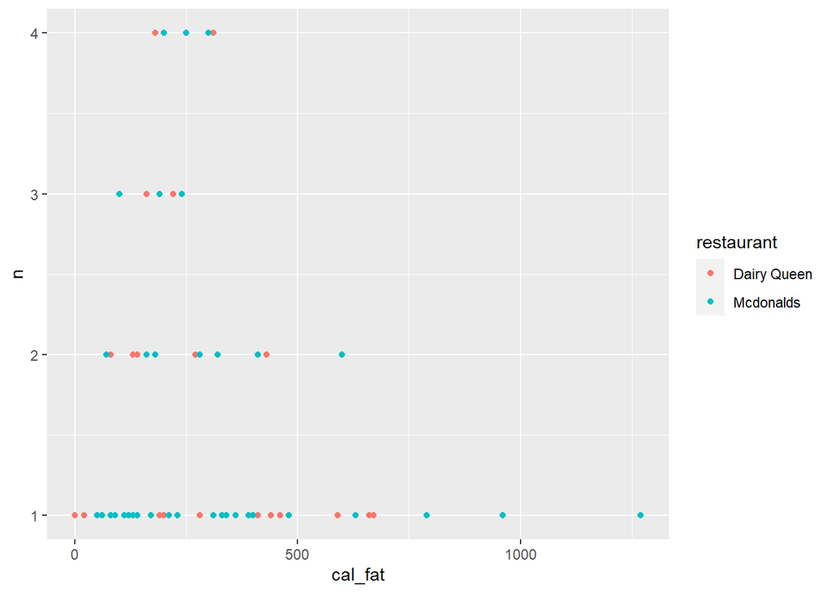

```r
ggplot(data = fastFoodSubset, aes(x = cal_fat, y = n, color= restaurant )) +
  geom_point()
```

When comparing and contrasting the data, McDonalds has a wider spread as well as significantly more options. This may be due to the fact of the menu composition as DQ appears to target ice cream whereas McDonalds is a mix of both food and ice cream. If we remove the extreme McDonalds values, theirs center should be approximately the same, and their shapes are remarkably close to each other.